# Analysis of House Sales Prices Dataset

Anna Kozak

## House Sales Prices Datset

The following analysis has been prepared on a data collection describing the sale of houses (House Sales Prices). Below is a list of variables:

## Variables

- `bedrooms` number of bedrooms
- `bathrooms` number of bathrooms, where .5 accounts for a room with a toilet but no shower
- `floors` number of floors
- `waterfront` apartment was overlooking the waterfront or not
- `view` how good the view of the property was
- `condition` condition of the apartment
- `grade` level of construction and design
- `zipcode` zipcode area
- `lat` lattitude
- `long` longitude
- `dist_stop` the distance from public transport
- `ncult` number of cultural facilities within a kilometre radius
- `age` age of house
- `since_renovated` number of age from the house’s last renovation
- `m2_living` square meter of the apartments interior living space
- `m2_lot` square meter of the land space
- `m2_above` the square meter of the interior housing space that is above ground level
- `m2_basement` the square meter of the interior housing space that is below ground level
- `m2_living15` the square meter of interior housing living space for the nearest 15 neighbors
- `m2_lot15` the square meter of the land lots of the nearest 15 neighbors
- `price_log` logarithm of price of each home sold

### Logarithm of price

Below is a density and boxplot plot describing the variable `price_log`.

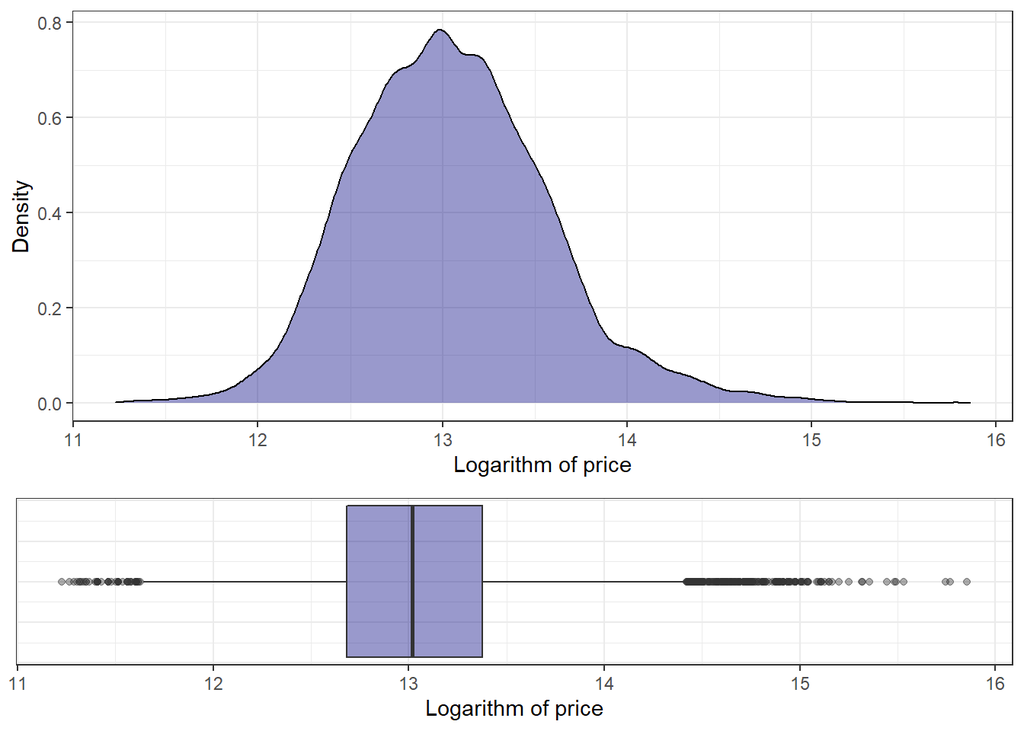

```r
p1 <- ggplot(data, aes(x=price_log)) +
  theme_bw() +
  geom_density(fill = "navy", alpha = 0.4) +
  labs(x = "Logarithm of price", y = "Density")
p2 <- ggplot(data, aes(x = price_log)) +
  theme_bw() +
  geom_boxplot(fill = "navy", alpha = 0.4) +
  theme(axis.text.y = element_blank(), axis.ticks.y = element_blank()) +
  labs(x = "Logarithm of price")

grid.arrange(p1, p2, nrow = 2, heights = c(2, 1))
```

### Relationship between logarithm of price and other variables

#### Number of bedrooms

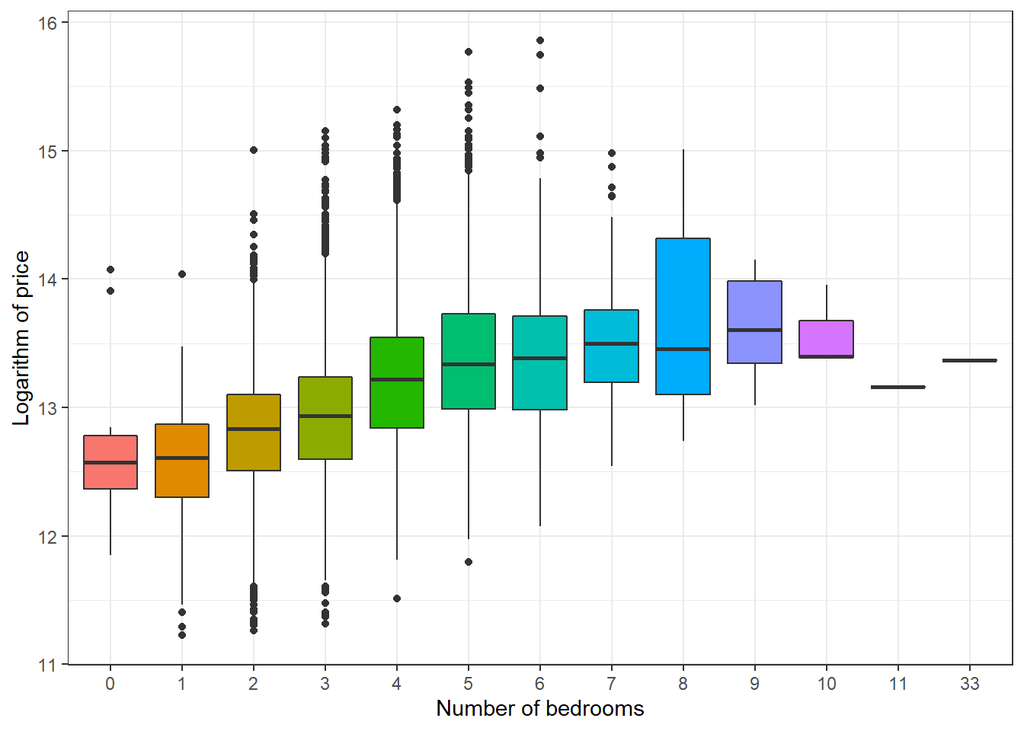

```r
ggplot(data, aes(x = as.factor(bedrooms), y = price_log, fill = as.factor(bedrooms))) +
  geom_boxplot() +
  theme_bw() +
  labs(x = "Number of bedrooms", y = "Logarithm of price", fill = "") +
  theme(legend.position = "none")
```

#### Number of bathrooms

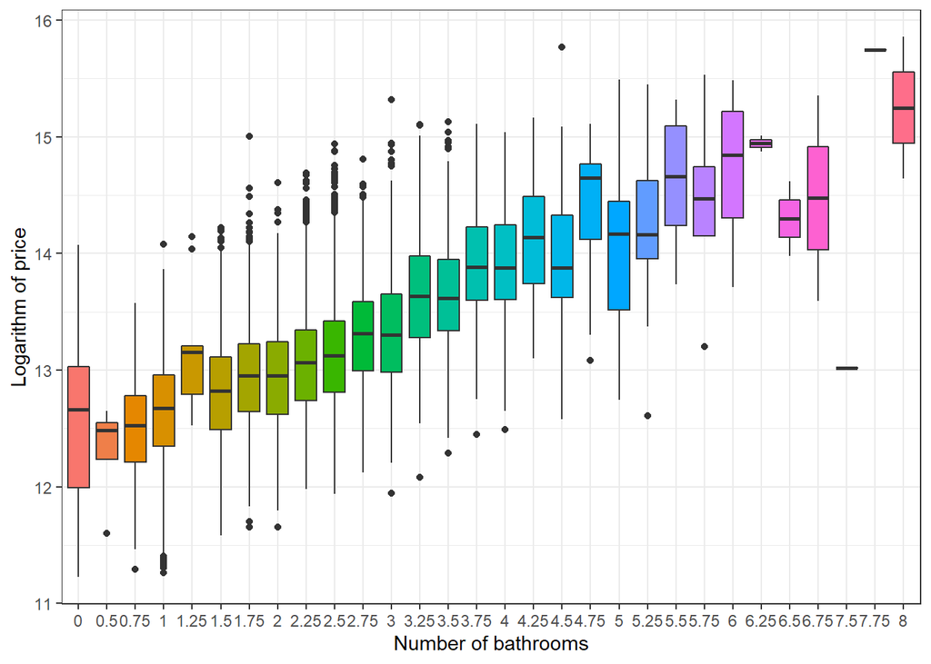

```r
ggplot(data, aes(x = as.factor(bathrooms), y = price_log, fill = as.factor(bathrooms))) +
  geom_boxplot() +
  theme_bw() +
  labs(x = "Number of bathrooms", y = "Logarithm of price", fill = "") +
  theme(legend.position = "none")
```

#### Number of floor

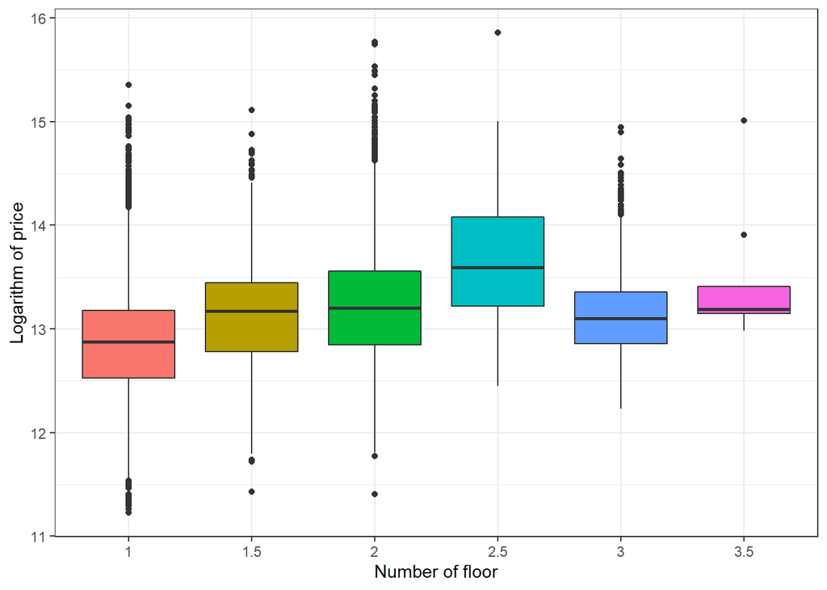

```r
ggplot(data, aes(x = as.factor(floors), y = price_log, fill = as.factor(floors))) +
  geom_boxplot() +
  theme_bw() +
  labs(x = "Number of floor", y = "Logarithm of price", fill = "") +
  theme(legend.position = "none")
```

#### Condition

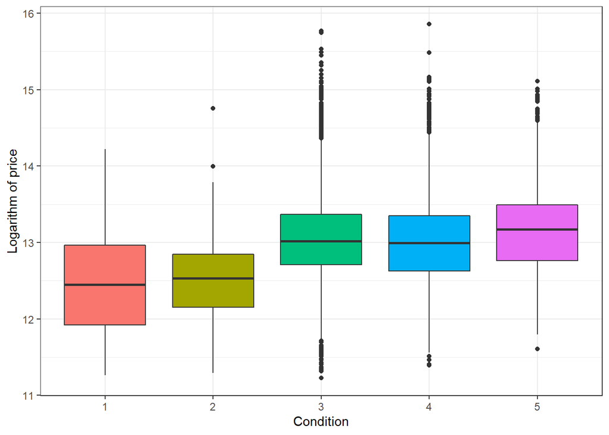

```r
ggplot(data, aes( x= as.factor(condition), y = price_log, fill = as.factor(condition))) +
  geom_boxplot() +
  theme_bw() +
  labs(x = "Condition", y = "Logarithm of price", fill = "") +
  theme(legend.position = "none")
```

#### Grade

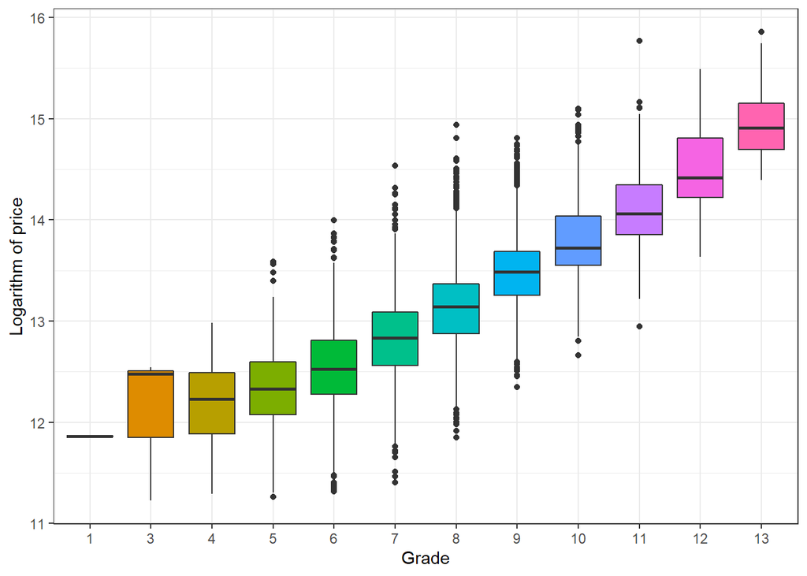

```r
ggplot(data, aes(x = as.factor(grade), y = price_log, fill = as.factor(grade))) +
  geom_boxplot() +
  theme_bw() +
  labs(x = "Grade", y = "Logarithm of price", fill = "") +
  theme(legend.position = "none")
```

#### Year of construction

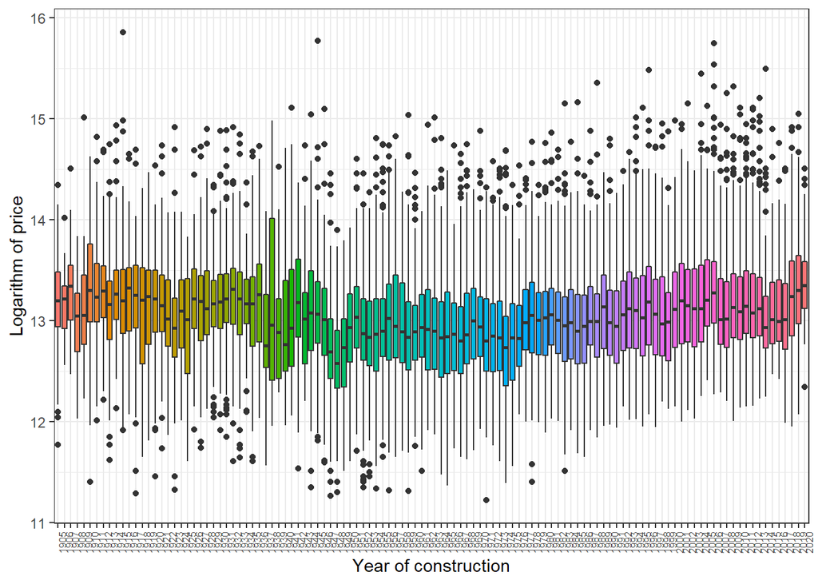

```r
ggplot(data, aes(x = as.factor(2020 - age), y = price_log, fill = as.factor(2020 - age))) +
  geom_boxplot() +
  theme_bw() +
  labs(x = "Year of construction", y = "Logarithm of price", fill = "") +
  theme(legend.position = "none") +
  theme(axis.text.x = element_text(angle = 90, hjust = 1, size = 6))
```

#### Construction year for property below 1 million

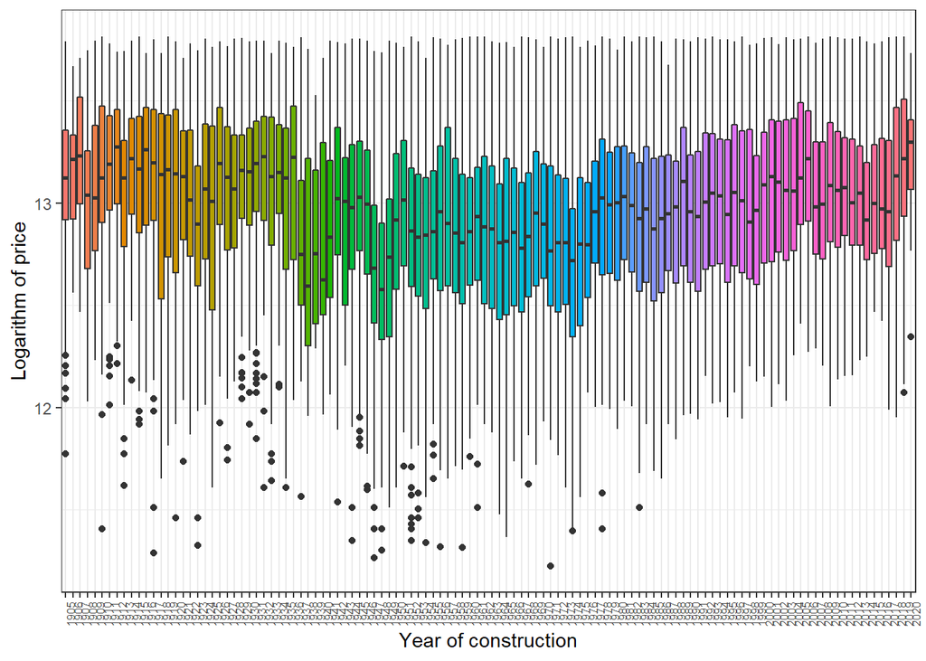

```r
ggplot(data[data$price_log < log(1000000),], aes(x = as.factor(2020 - age), y = price_log, fill = as.factor(2020 - age))) +
  geom_boxplot() +
  theme_bw() +
  labs(x = "Year of construction", y = "Logarithm of price", fill = "") +
  theme(legend.position = "none") +
  theme(axis.text.x = element_text(angle = 90, size = 6))
```

#### View

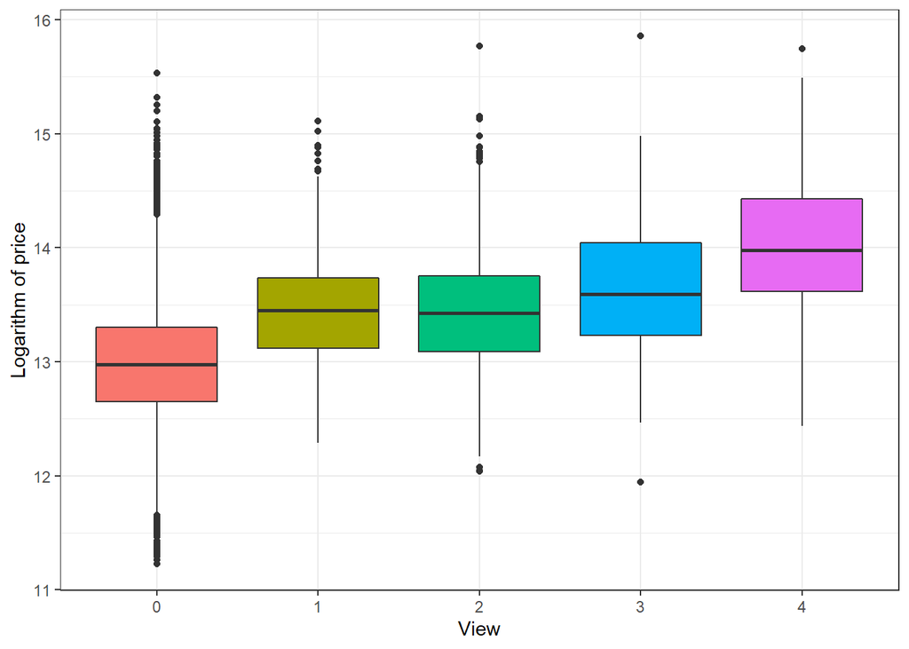

```r
ggplot(data, aes(x = as.factor(view), y = price_log, fill = as.factor(view))) +
  geom_boxplot() +
  theme_bw() +
  labs(x = "View", y = "Logarithm of price", fill = "") +
  theme(legend.position = "none")
```

### Other dependencies

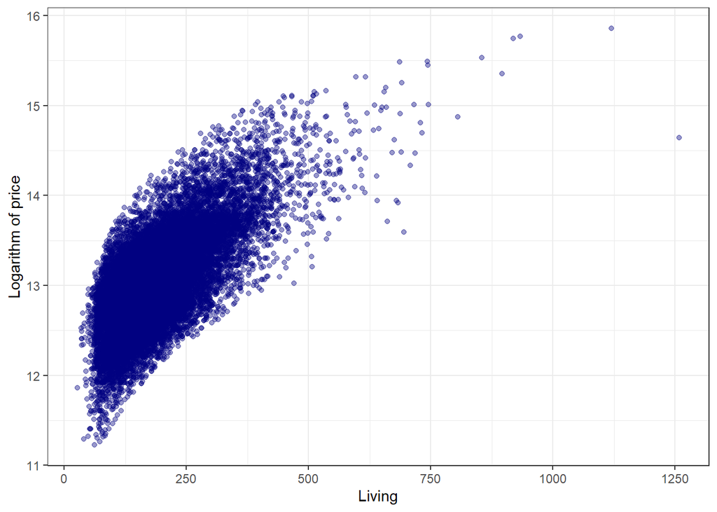

```r
ggplot(data, aes(x = m2_living, y = price_log)) +
  geom_point(color = "navy", alpha = 0.4) +
  theme_bw() +
  labs(x = "Living", y = "Logarithm of price")
```

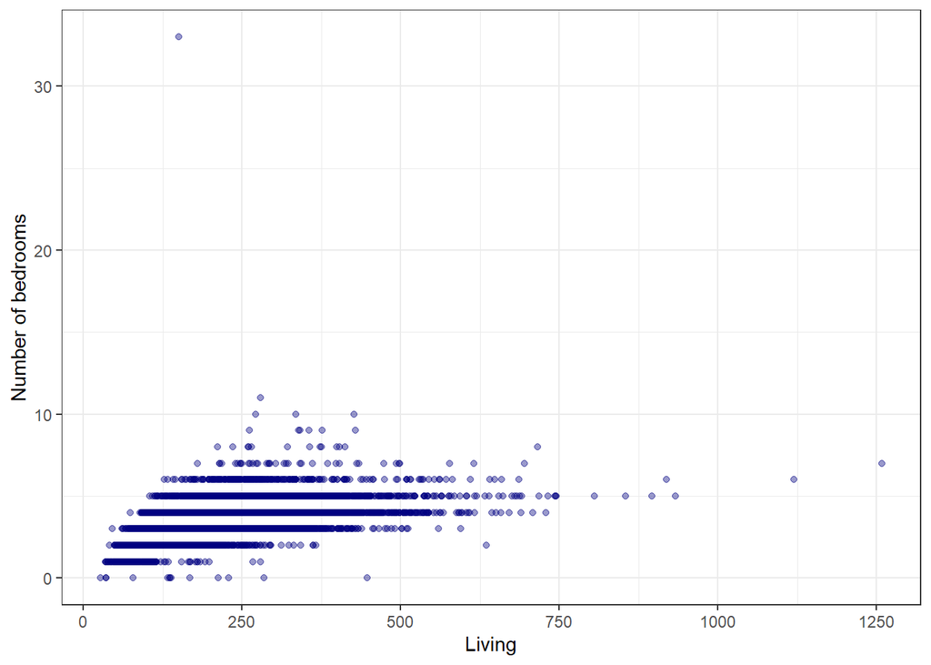

```r
ggplot(data, aes(x = m2_living, y = bedrooms)) +
  geom_point(color = "navy", alpha = 0.4) +
  theme_bw() +
  labs(x = "Living", y = "Number of bedrooms")
```

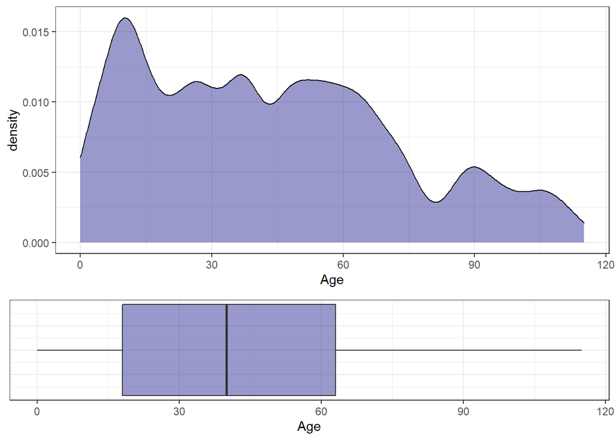

```r
p3 <- ggplot(data, aes(x = age)) +
  geom_density(fill = "navy", alpha = 0.4) +
  theme_bw() +
  labs(x = "Age")
p4 <- ggplot(data, aes(x = age)) +
  theme_bw() +
  geom_boxplot(fill = "navy", alpha = 0.4) +
  theme(axis.text.y = element_blank(), axis.ticks.y = element_blank()) +
  labs(x = "Age")

grid.arrange(p3, p4, nrow = 2, heights = c(2, 1))
```

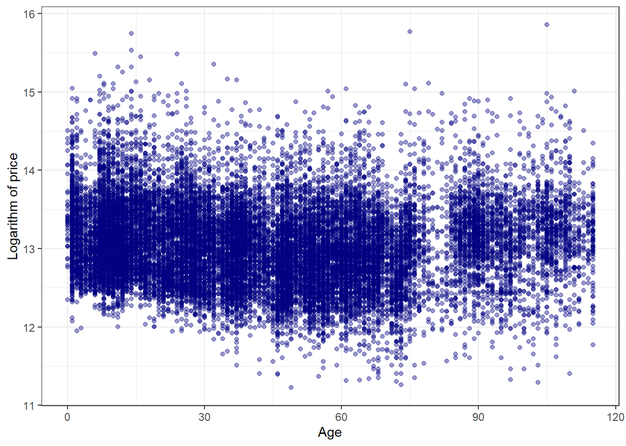

```r
ggplot(data, aes(x = age, y = price_log)) +
  geom_point(color = "navy", alpha = 0.4) +
  theme_bw() +
  labs(x = "Age", y = "Logarithm of price")
```

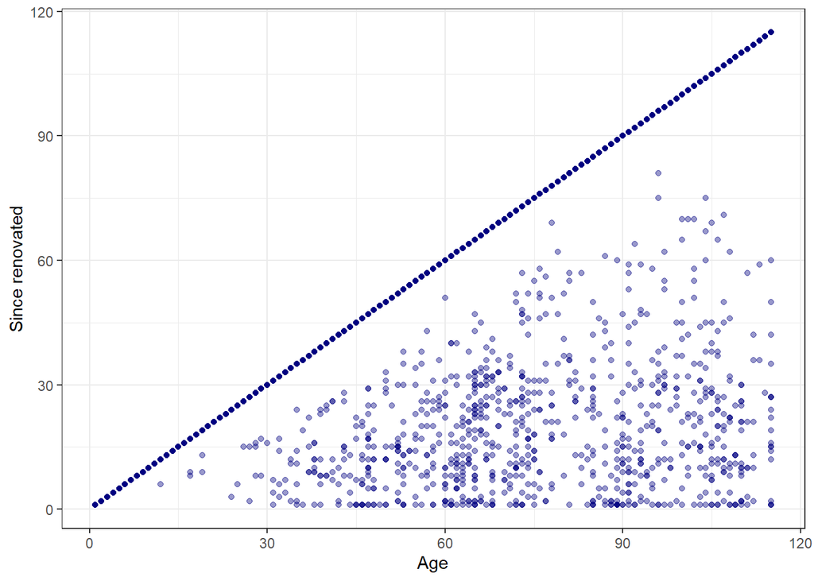

```r
ggplot(data[data$since_renovated != 0,], aes(x = age, y = since_renovated)) +
  geom_point(color = "navy", alpha = 0.4) +
  theme_bw() +
  labs(x = "Age", y = "Since renovated")
```

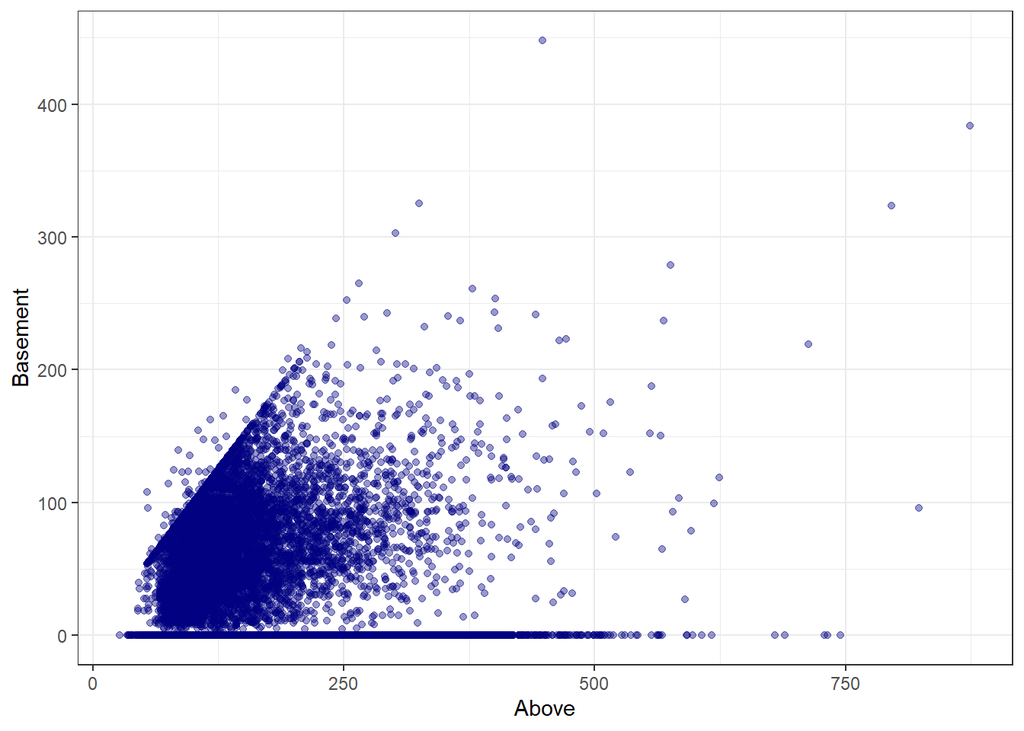

```r
ggplot(data, aes(x = m2_above, y = m2_basement)) +
  theme_bw() +
  geom_point(color = "navy", alpha = 0.4) +
  labs(x = "Above", y = "Basement")
```

### Table

#### Number of bedrooms vs number of bathrooms

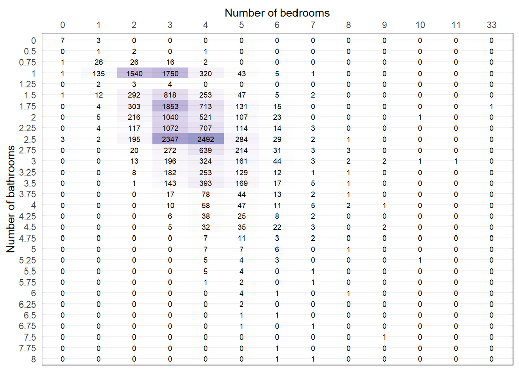

```r
data.frame(table(data$bedrooms, data$bathrooms)) -> t
names(t) <- c("Bedrooms", "Bathrooms", "Freq")


ggplot(t, aes(x = Bedrooms, y = Bathrooms, fill = Freq, label = Freq)) +
  geom_tile(alpha = 0.4) +
  scale_fill_gradient(low = "white", high = "navy") +
  theme_bw() +
  geom_text(size = 2.5) +
  scale_x_discrete(position = "top") +
  scale_y_discrete(limits = rev(levels(t$Bathrooms))) +
  labs(x = "Number of bedrooms", y = "Number of bathrooms", fill = "") +
  theme(legend.position = "none", axis.ticks.x = element_blank(), axis.ticks.y = element_blank())
```

#### Condition vs number of bathrooms

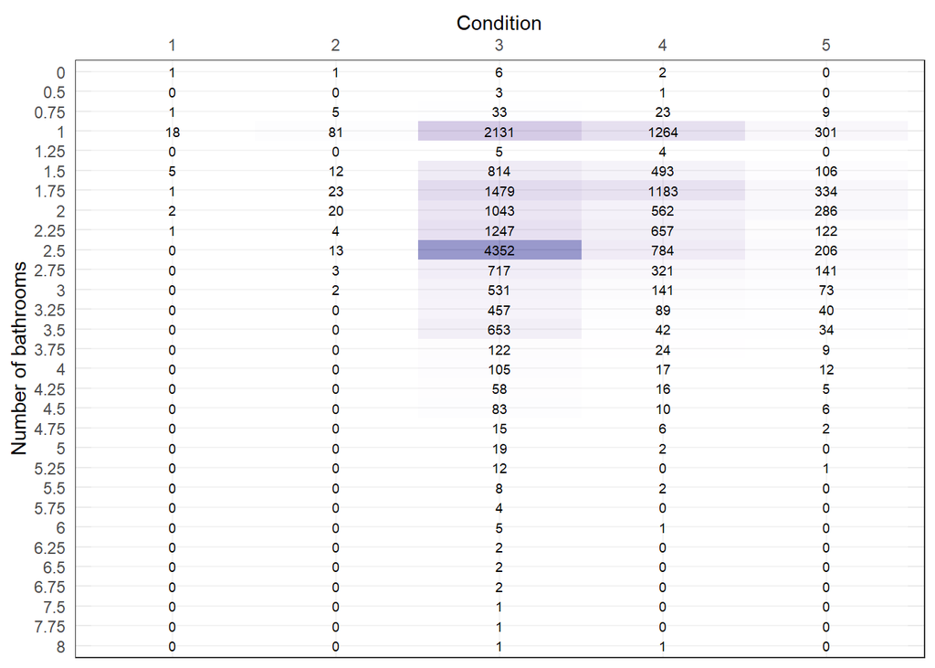

```r
data.frame(table(data$bathrooms, data$condition)) -> t
names(t) <- c("Bathrooms", "Condition", "Freq")


ggplot(t, aes(x = Condition, y = Bathrooms, fill = Freq, label = Freq)) +
  geom_tile(alpha = 0.4) +
  scale_fill_gradient(low = "white", high = "navy") +
  theme_bw() +
  geom_text(size = 2.5) +
  scale_x_discrete(position = "top") +
  scale_y_discrete(limits = rev(levels(t$Bathrooms))) +
  labs(x = "Condition", y = "Number of bathrooms", fill = "") +
  theme(legend.position = "none", axis.ticks.x = element_blank(), axis.ticks.y = element_blank())
```

[figure not shown]

```r
data.frame(table(data$bedrooms, data$condition)) -> t
names(t) <- c("Bedrooms", "Condition", "Freq")


ggplot(t, aes(x = Condition, y = Bedrooms, fill = Freq, label = Freq)) +
  geom_tile(alpha = 0.4) +
  scale_fill_gradient(low = "white", high = "navy") +
  theme_bw() +
  geom_text(size = 2.5) +
  scale_x_discrete(position = "top") +
  scale_y_discrete(limits = rev(levels(t$Bedrooms))) +
  labs(x = "Condition", y = "Number of bathrooms", fill = "") +
  theme(legend.position = "none", axis.ticks.x = element_blank(), axis.ticks.y = element_blank())
```

#### Waterfront vs condition

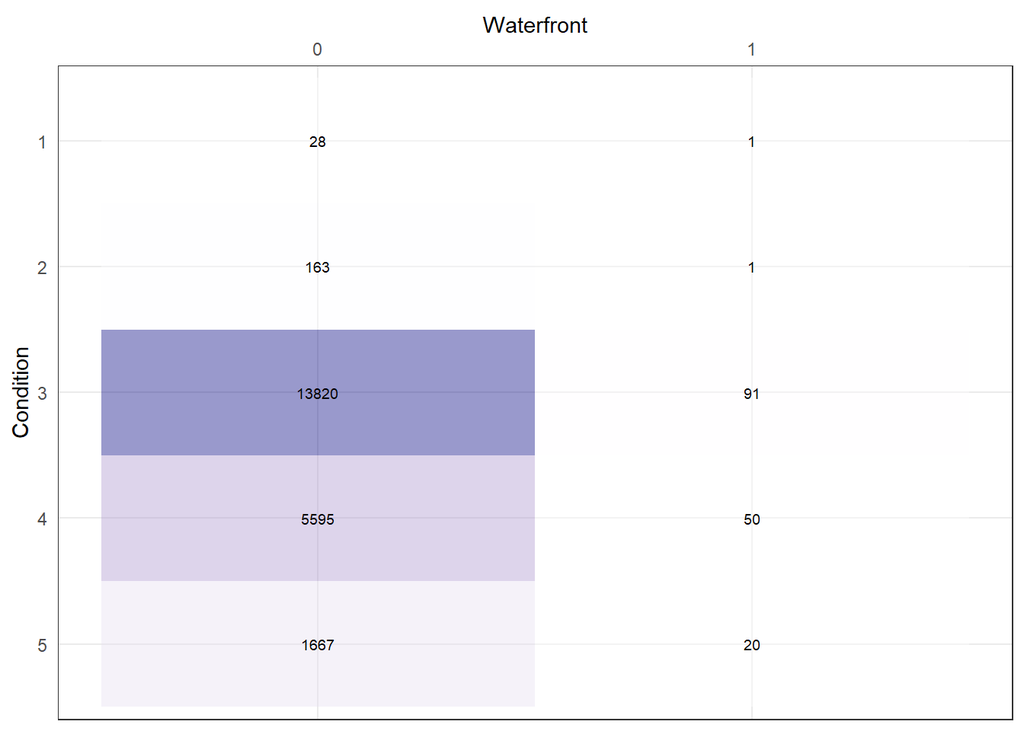

```r
data.frame(table(data$waterfront, data$condition)) -> t
names(t) <- c("Waterfront", "Condition", "Freq")


ggplot(t, aes(x = Waterfront, y = Condition, fill = Freq, label = Freq)) +
  geom_tile(alpha = 0.4) +
  scale_fill_gradient(low = "white", high = "navy") +
  theme_bw() +
  geom_text(size = 2.5) +
  scale_x_discrete(position = "top") +
  scale_y_discrete(limits = rev(levels(t$Condition))) +
  labs(x = "Waterfront", y = "Condition", fill = "") +
  theme(legend.position = "none", axis.ticks.x = element_blank(), axis.ticks.y = element_blank())
```

#### Condition vs Grade

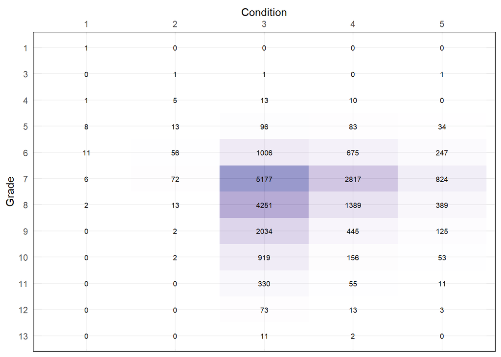

```r
data.frame(table(data$grade, data$condition)) -> t
names(t) <- c("Grade", "Condition", "Freq")


ggplot(t, aes(x = Condition, y = Grade, fill = Freq, label = Freq)) +
  geom_tile(alpha = 0.4) +
  scale_fill_gradient(low = "white", high = "navy") +
  theme_bw() +
  geom_text(size = 2.5) +
  scale_x_discrete(position = "top") +
  scale_y_discrete(limits = rev(levels(t$Grade))) +
  labs(x = "Condition", y = "Grade", fill = "") +
  theme(legend.position = "none", axis.ticks.x = element_blank(), axis.ticks.y = element_blank())
```

#### Number of bedrooms vs grade

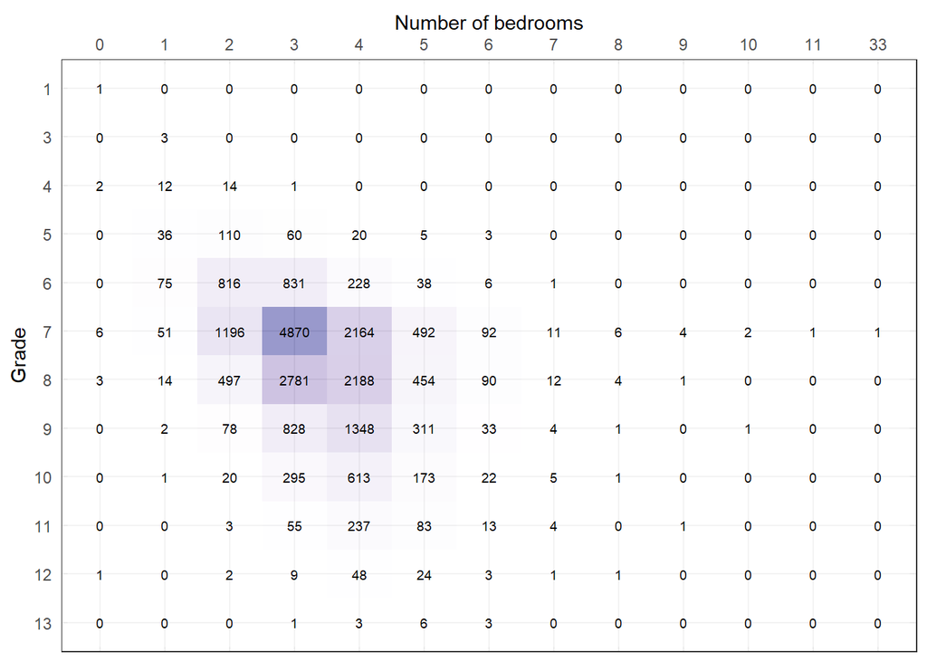

```r
data.frame(table(data$grade, data$bedrooms)) -> t
names(t) <- c("Grade", "Bedrooms", "Freq")


ggplot(t, aes(x = Bedrooms, y = Grade, fill = Freq, label = Freq)) +
  geom_tile(alpha = 0.4) +
  scale_fill_gradient(low = "white", high = "navy") +
  theme_bw() +
  geom_text(size = 2.5) +
  scale_x_discrete(position = "top") +
  scale_y_discrete(limits = rev(levels(t$Grade))) +
  labs(x = "Number of bedrooms", y = "Grade", fill = "") +
  theme(legend.position = "none", axis.ticks.x = element_blank(), axis.ticks.y = element_blank())
```

#### Number of bathrooms vs grade

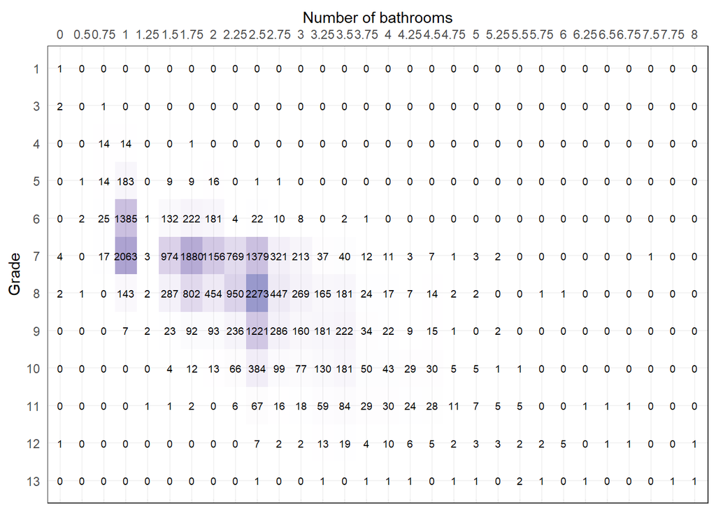

```r
data.frame(table(data$grade, data$bathrooms)) -> t
names(t) <- c("Grade", "Bathrooms", "Freq")


ggplot(t, aes(x = Bathrooms, y = Grade, fill = Freq, label = Freq)) +
  geom_tile(alpha = 0.4) +
  scale_fill_gradient(low = "white", high = "navy") +
  theme_bw() +
  geom_text(size = 2.5) +
  scale_x_discrete(position = "top") +
  scale_y_discrete(limits = rev(levels(t$Grade))) +
  labs(x = "Number of bathrooms", y = "Grade", fill = "") +
  theme(legend.position = "none", axis.ticks.x = element_blank(), axis.ticks.y = element_blank())
```